# Project 2: Data Mining, Classification, Prediction

SDS322E

# Mining, Classification, Prediction

Astrid Herrera (ach3678)

### Introduction

My dataset consists of auction data from Ebay for the game Mario Kart on the Nintendo Wii from the year 2009, specifically 143 instances at which a copy of the game was purchased from the website. The ‘ID’ variable is the unique Auction ID for each sale, ‘auctionDuration’ is how long the auction was in days, ‘nBids’ is total number of bids for the game, ‘Condition’ is a binary variable indicating if the game was new or used, ‘startPrice’ is the initial price for an auction, ‘shipPrice’ is how much was spent in shipping, ‘totalPrice’ is the price at the end of an auction plus shipping fees, ‘shipMethod’ is the speed or method that the game was shipped out to the buyer, ‘sellerRating’ is the number of positive rating minus negative ratings for the seller, ‘stockPhoto’ indicates whether the featured auction photo was unique or a stock image of the video game, ‘nWheels’ is the number of Wii driving wheels sold with the game, and ‘listingTitle’ is the name of the auction. All of the price variables are in US Dollars.

I found this dataset in the packge openintro in a list of R datasets from the website https://vincentarelbundock.github.io/Rdatasets/datasets.html and was drawn to it just because I love Mario Kart.

```r
library(tidyverse)
library(openintro)
data(mariokart)
names(mariokart) <- c("Id", "auctionDuration", "nBids", "Condition",
    "startPrice", "shipPrice", "totalPrice", "shipMethod", "sellerRating",
    "stockPhoto", "nWheels", "listingTitle")
```

### Cluster Analysis

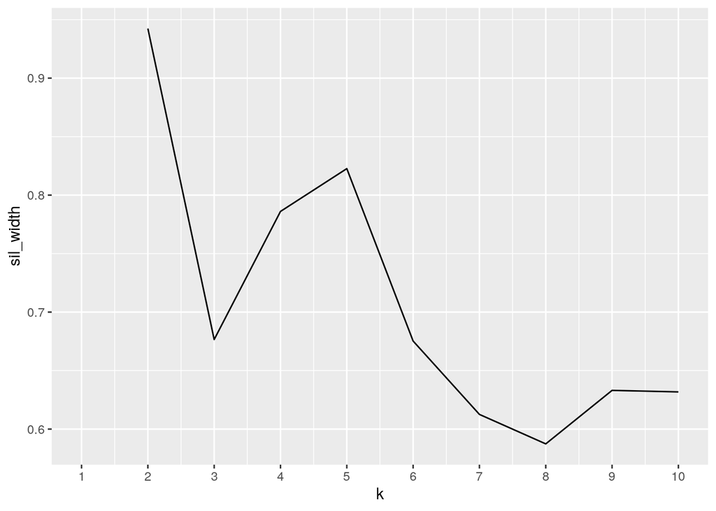

```r
library(tidyverse)
library(cluster)

clust_dat <- mariokart %>% dplyr::select(nBids, startPrice, shipPrice,
    totalPrice, sellerRating)
sil_width <- vector()
for (i in 2:10) {
    kms <- kmeans(clust_dat, centers = i)
    sil <- silhouette(kms$cluster, dist(clust_dat))
    sil_width[i] <- mean(sil[, 3])  #
}
ggplot() + geom_line(aes(x = 1:10, y = sil_width)) + scale_x_continuous(name = "k",
    breaks = 1:10)
```

```r
# k=2 is best :)
pam1 <- clust_dat %>% pam(k = 2)
pam1
```

```
## Medoids:
##       ID nBids startPrice shipPrice totalPrice sellerRating
## [1,]  14    16       0.01         0         56          820
## [2,] 111    16       0.99         4         43       270143
## Clustering vector:
##   [1] 1 1 1 1 1 2 1 1 1 1 1 1 1 1 1 1 1 1 1 1 1 1 1 1 1 1 1 1 1 1 1 1 1 1 1 1 1
##  [38] 1 1 1 1 1 1 1 1 1 1 1 1 1 1 1 1 2 1 1 1 1 1 1 1 1 1 1 1 1 1 1 1 1 1 1 1 1
##  [75] 1 1 1 1 2 1 1 1 1 1 1 1 1 1 1 1 1 1 1 1 1 1 2 1 1 1
##  [ reached getOption("max.print") -- omitted 43 entries ]
## Objective function:
##    build     swap
## 6946.708 6946.708
##
## Available components:
##  [1] "medoids"    "id.med"     "clustering" "objective"  "isolation"
##  [6] "clusinfo"   "silinfo"    "diss"       "call"       "data"
```

```r
pamclust <- clust_dat %>% mutate(cluster = as.factor(pam1$clustering))
pamclust %>% group_by(cluster) %>% summarize_if(is.numeric, mean,
    na.rm = T)
```

```
## # A tibble: 2 x 6
##   cluster nBids startPrice shipPrice totalPrice sellerRating
##   <fct>   <dbl>      <dbl>     <dbl>      <dbl>        <dbl>
## 1 1        13.5       8.69      3.14       50.1        7022.
## 2 2        14.8      11.2       3.2        45.0      260887.
```

```r
mariokart %>% slice(pam1$id.med)
```

```
## # A tibble: 2 x 12
##        Id auctionDuration nBids Condition startPrice shipPrice totalPrice
##     <dbl>           <int> <int> <fct>          <dbl>     <dbl>      <dbl>
## 1 1.80e11               1    16 new             0.01         0         56
## 2 3.60e11               3    16 used            0.99         4         43
## # … with 5 more variables: shipMethod <fct>, sellerRating <int>,
## #   stockPhoto <fct>, nWheels <int>, listingTitle <fct>
```

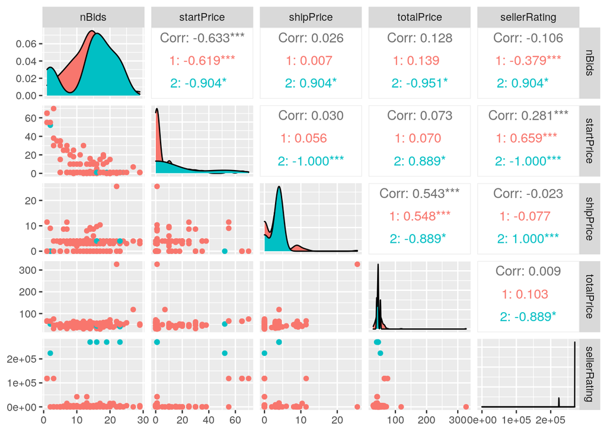

```r
library(GGally)
mariokart %>% mutate(cluster = as.factor(pam1$clustering)) %>%
    ggpairs(columns = c("nBids", "startPrice", "shipPrice", "totalPrice",
        "sellerRating"), aes(color = cluster))
```

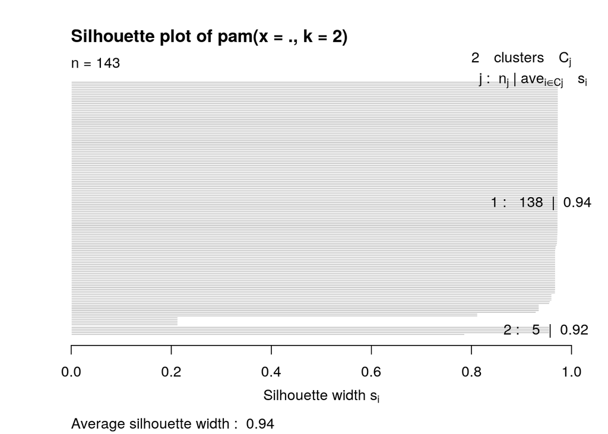

```r
plot(pam1, which = 2)
```

The best number of clusters for this clustering solution was determined to be k=2 by computing silhouette width. For the two clusters generated, the second cluster had the highest average values for all variables except totalPrice. The two videogame auctions that represent the medoids for each cluster were found to be the most different for the variable ‘sellerRating’, and exactly the same for variable ‘nBids’. The variables ‘nBids’ and ‘shipPrice’ visually show the least difference between the two clusters while it appears that the variables ‘startPrice’ and ‘sellerRating’ show the most difference between the two clusters. The second teal cluster shows a more uniform distribution for values of the variable ‘startPrice’ than the first pink cluster. The overall overage silhouette width of 0.94 offers a strong cluster solution.

### Dimensionality Reduction with PCA

```r
mkpca <- princomp(mariokart %>% dplyr::select(nBids, startPrice,
    shipPrice, totalPrice, sellerRating), cor = T)
summary(mkpca, loadings = T)
```

```
## Importance of components:
##                           Comp.1    Comp.2    Comp.3     Comp.4    Comp.5
## Standard deviation     1.3189784 1.2465950 0.9620227 0.69292557 0.5483279
## Proportion of Variance 0.3479408 0.3107998 0.1850975 0.09602917 0.0601327
## Cumulative Proportion  0.3479408 0.6587406 0.8438381 0.93986730 1.0000000
##
## Loadings:
##              Comp.1 Comp.2 Comp.3 Comp.4 Comp.5
## nBids         0.643         0.391  0.213  0.623
## startPrice   -0.670  0.156 -0.102  0.298  0.654
## shipPrice            0.693        -0.678  0.209
## totalPrice           0.701         0.617 -0.342
## sellerRating -0.348         0.908 -0.159 -0.157
```

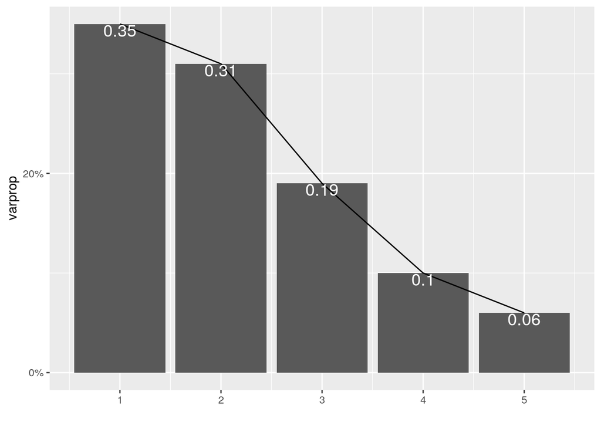

```r
eigval <- mkpca$sdev^2
varprop = round(eigval/sum(eigval), 2)
ggplot() + geom_bar(aes(y = varprop, x = 1:5), stat = "identity") +
    xlab("") + geom_path(aes(y = varprop, x = 1:5)) + geom_text(aes(x = 1:5,
    y = varprop, label = round(varprop, 2)), vjust = 1, col = "white",
    size = 5) + scale_y_continuous(breaks = seq(0, 0.6, 0.2),
    labels = scales::percent) + scale_x_continuous(breaks = 1:10)
```

```r
round(cumsum(eigval)/sum(eigval), 2)
```

```
## Comp.1 Comp.2 Comp.3 Comp.4 Comp.5
##   0.35   0.66   0.84   0.94   1.00
```

```r
eigval
```

```
##    Comp.1    Comp.2    Comp.3    Comp.4    Comp.5
## 1.7397040 1.5539990 0.9254877 0.4801459 0.3006635
```

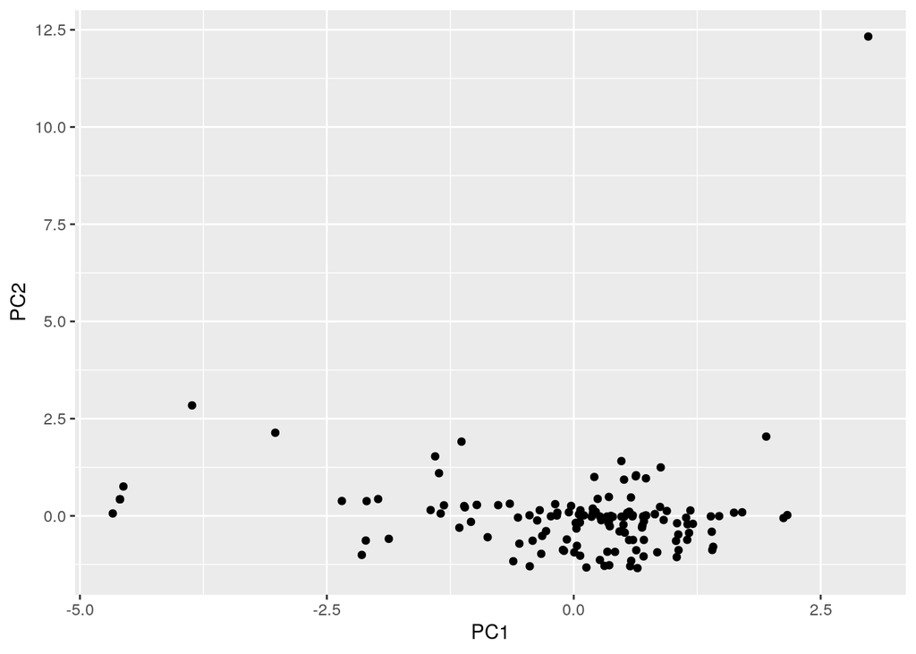

```r
# matrix <- mkpca$scores %>% as.data.frame%>%
# mutate(Condition = as.factor(mariokart$Condition)) matrix
# %>% ggplot(aes(Comp.1, Comp.2, color=Condition)) +
# geom_point(size=1) + xlab('PC1') +ylab('PC2')

mariokartdf <- data.frame(PC1 = mkpca$scores[, 1], PC2 = mkpca$scores[,
    2])
ggplot(mariokartdf, aes(PC1, PC2)) + geom_point()
```

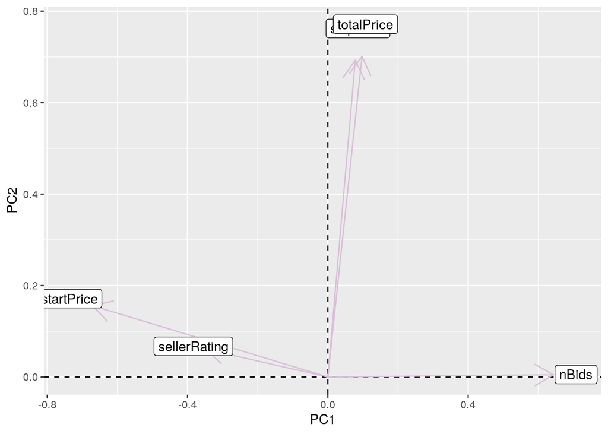

```r
mkpca$loadings[1:5, 1:2] %>% as.data.frame %>% rownames_to_column %>%
    ggplot() + geom_hline(aes(yintercept = 0), lty = 2) + geom_vline(aes(xintercept = 0),
    lty = 2) + ylab("PC2") + xlab("PC1") + geom_segment(aes(x = 0,
    y = 0, xend = Comp.1, yend = Comp.2), arrow = arrow(), col = "thistle") +
    geom_label(aes(x = Comp.1 * 1.1, y = Comp.2 * 1.1, label = rowname))
```

PC1 is an axis of number of bids vs. starting price and the seller’s rating. So a high score for PC1 indicates that there was a large amount of bids, the starting price was low, and the seller’s Ebay rating was low as well. This could indicate a trend among this dataset that auctions will have higher activity regardless of seller rating if the starting price is low enough. PC2 is a general price axis because all loadings have the same sign, so the higher an auction scores for PC2 the more amount of money was paid for the video game overall. Only the first two PCs were retained because including the third PC was mean that the cumulative proportion of variance was greater than 80%, and only the eigenvalues for PC1 and PC2 were greater than 1. PC1 and PC2 represent approximately 66% of the total variance across the variables nBids, startPrice, shipPrice, and totalPrice. A plot of PC1 and PC2 scores for all 143 purchases was created and indicates an outlier with exceedingly high PC1 and PC2 score, which is problematic considering PCA is senstive to outliers. A loading plot further indicates how variables ‘nBids’, ‘startPrice’, and ‘sellerRating’ contribute the most to PC1 and how variables ‘shipPrice’ and ‘totalPrice’ contribute heavily to PC2, while ‘startPrice’ only somewhat contributes to PC2.